# Regresión lineal

Mario Encinar

# Instrucciones para ajustar modelos lineales en R

La instrucción para ajustar un modelo lineal en R es `lm`:

`lm(formula, data, subset, weights, ...)`

donde

- `formula` es una descripción simbólica del modelo que se pretende ajustar.
- `data` es un *data frame* que contiene los datos con los que se pretende ajustar el modelo.
- `subset` es un vector opcional que especifica el subconjunto de observaciones que se van a usar en el proceso de ajuste.
- `weights` es un vector opcional de pesos que se van a usar en el proceso de ajuste del modelo. Por defecto `weights=NULL`, indicando que el ajuste se realizará por mínimos cuadrados ordinarios, y, en caso contrario, si se pasa un vector $w = (w_1, \dots, w_n)$, la función que se minimiza en el ajuste del modelo es el $MSE$ ponderado por $W$, es decir,
  $$MSE_w = \sum_{i=1}^{n} w_i e_i^2.$$

# El dataset `Advertising`

```r
library(dplyr)
advertising <- read.csv('advertising.csv', sep = ';', header = T, fileEncoding = 'utf-8')
glimpse(advertising)
```

```
## Observations: 200
## Variables: 4
## $ TV        <dbl> 230.1, 44.5, 17.2, 151.5, 180.8, 8.7, 57.5, 120.2, 8...
## $ Radio     <dbl> 37.8, 39.3, 45.9, 41.3, 10.8, 48.9, 32.8, 19.6, 2.1,...
## $ Newspaper <dbl> 69.2, 45.1, 69.3, 58.5, 58.4, 75.0, 23.5, 11.6, 1.0,...
## $ Sales     <dbl> 22.1, 10.4, 9.3, 18.5, 12.9, 7.2, 11.8, 13.2, 4.8, 1...
```

```r
summary(advertising)
```

```
##        TV             Radio          Newspaper          Sales
##  Min.   :  0.70   Min.   : 0.000   Min.   :  0.30   Min.   : 1.60
##  1st Qu.: 74.38   1st Qu.: 9.975   1st Qu.: 12.75   1st Qu.:10.38
##  Median :149.75   Median :22.900   Median : 25.75   Median :12.90
##  Mean   :147.04   Mean   :23.264   Mean   : 30.55   Mean   :14.02
##  3rd Qu.:218.82   3rd Qu.:36.525   3rd Qu.: 45.10   3rd Qu.:17.40
##  Max.   :296.40   Max.   :49.600   Max.   :114.00   Max.   :27.00
```

# Diagramas de dispersión por pares

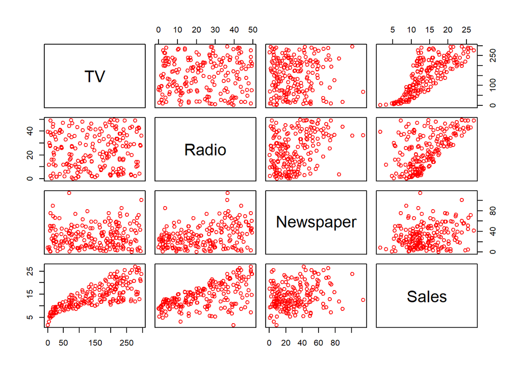

```r
pairs(advertising, col = 'red')
```

# Ajuste de un modelo lineal simple

`Sales` frente a `TV`:

```r
lm_fit_sales_TV <- lm(Sales ~ TV, data = advertising)

lm_fit_sales_TV
```

```
##
## Call:
## lm(formula = Sales ~ TV, data = advertising)
##
## Coefficients:
## (Intercept)           TV
##     7.03259      0.04754
```

El modelo es

$$Sales = 7.03259 + 0.04754\cdot TV$$

```r
summary(lm_fit_sales_TV)
```

```
##
## Call:
## lm(formula = Sales ~ TV, data = advertising)
##
## Residuals:
##     Min      1Q  Median      3Q     Max
## -8.3860 -1.9545 -0.1913  2.0671  7.2124
##
## Coefficients:
##             Estimate Std. Error t value Pr(>|t|)
## (Intercept) 7.032594   0.457843   15.36   <2e-16 ***
## TV          0.047537   0.002691   17.67   <2e-16 ***
## ---
## Signif. codes:  0 '***' 0.001 '**' 0.01 '*' 0.05 '.' 0.1 ' ' 1
##
## Residual standard error: 3.259 on 198 degrees of freedom
## Multiple R-squared:  0.6119, Adjusted R-squared:  0.6099
## F-statistic: 312.1 on 1 and 198 DF,  p-value: < 2.2e-16
```

```r
names(lm_fit_sales_TV)
```

```
##  [1] "coefficients"  "residuals"     "effects"       "rank"
##  [5] "fitted.values" "assign"        "qr"            "df.residual"
##  [9] "xlevels"       "call"          "terms"         "model"
```

Se pueden obtener intervalos de confianza para los coeficientes

```r
confint(lm_fit_sales_TV, level = 0.95)
```

```
##                  2.5 %     97.5 %
## (Intercept) 6.12971927 7.93546783
## TV          0.04223072 0.05284256
```

y se pueden hacer predicciones para datos nuevos

```r
new_advertising = data.frame(TV = c(100, 150, 200, 250))
predicted_values <- predict(lm_fit_sales_TV, new_advertising, interval = 'confidence')
new_advertising <- cbind(new_advertising, predicted_values)
new_advertising
```

```
##    TV      fit      lwr      upr
## 1 100 11.78626 11.26782 12.30470
## 2 150 14.16309 13.70842 14.61776
## 3 200 16.53992 16.00567 17.07418
## 4 250 18.91675 18.20619 19.62732
```

Podemos representar gráficamente el modelo sobre los datos de entrenamiento:

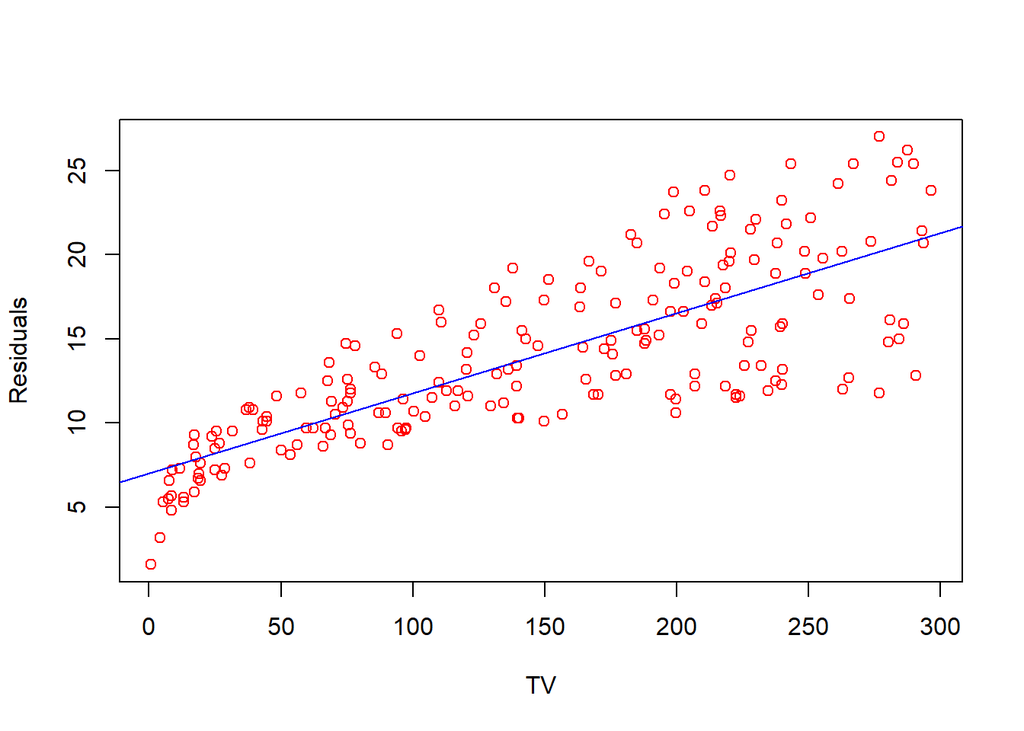

```r
plot(advertising$TV, advertising$Sales, type = 'p', col = 'red', xlab = 'TV', ylab = 'Residuals')
abline(lm_fit_sales_TV, col = 'blue')
```

Por último, también podemos representar gráficamente los residuos del modelo:

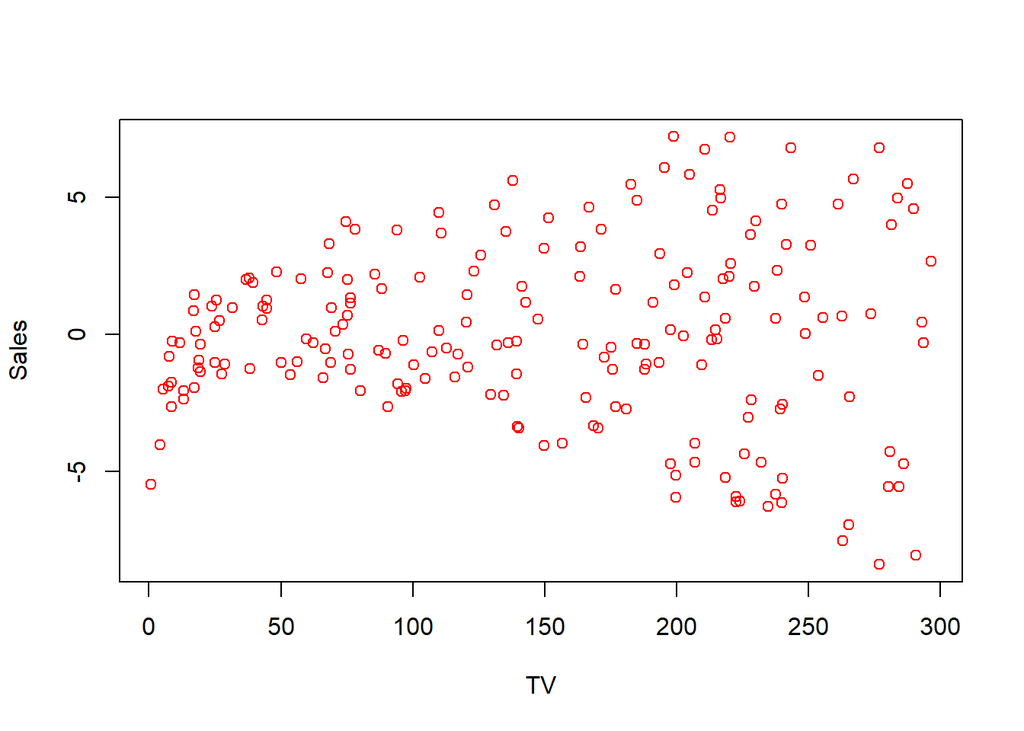

```r
plot(advertising$TV, lm_fit_sales_TV$residuals, type = 'p', col = 'red', xlab = 'TV', ylab = 'Sales')
```

**Ejercicio:** Considera el dataset `Auto`, que tienes disponible en el fichero `auto.csv` (puedes encontrar la descripción del dataset en la segunda página de [esto](https://cran.r-project.org/web/packages/ISLR/ISLR.pdf)).

- Ajusta un modelo lineal de `mpg` frente a `horsepower` y comenta los resultados. Por ejemplo:

```r
Auto <- read.csv('auto.csv',sep = ";")

attach(Auto)

lm_fit <- lm(mpg ~ horsepower)
```

- ¿Existe relación entre el predictor y la respuesta?

A priori la correlación entre predictor y respuesta es alta:

```r
cor(horsepower, mpg)
```

```
## [1] -0.7784268
```

Según el primer modelo:

```r
summary(lm_fit)
```

```
##
## Call:
## lm(formula = mpg ~ horsepower)
##
## Residuals:
##      Min       1Q   Median       3Q      Max
## -13.5710  -3.2592  -0.3435   2.7630  16.9240
##
## Coefficients:
##              Estimate Std. Error t value Pr(>|t|)
## (Intercept) 39.935861   0.717499   55.66   <2e-16 ***
## horsepower  -0.157845   0.006446  -24.49   <2e-16 ***
## ---
## Signif. codes:  0 '***' 0.001 '**' 0.01 '*' 0.05 '.' 0.1 ' ' 1
##
## Residual standard error: 4.906 on 390 degrees of freedom
## Multiple R-squared:  0.6059, Adjusted R-squared:  0.6049
## F-statistic: 599.7 on 1 and 390 DF,  p-value: < 2.2e-16
```

El coeficiente que va con `horsepower` es estadísticamente significativo (como el *p-valor* es muy pequeño rechazamos la hipótesis nula de que el coeficiente sea cero), luego existe relación entre el predictor y la respuesta `mpg`.

- ¿Cómo de fuerte es esa relación?

Según el valor del coeficiente de la regresión, por cada unidad de `horsepower`, la respuesta `mpg` decrece en -0.158 unidades.

- ¿Es la relación entre el predictor y la respuesta positiva o negativa?

Negativa.

- ¿Cuál es el `mpg` predicho para un `horsepower` de 98? Da un intervalo de confianza del 99% para ese valor.

```r
new_hp <- data.frame(horsepower = 98)

predicted_values <- predict(lm_fit, new_hp, interval = 'confidence', level = 0.99)
predicted_values
```

```
##        fit      lwr      upr
## 1 24.46708 23.81669 25.11747
```

- Representa gráficamente la respuesta y el predictor, así como el modelo que has ajustado.

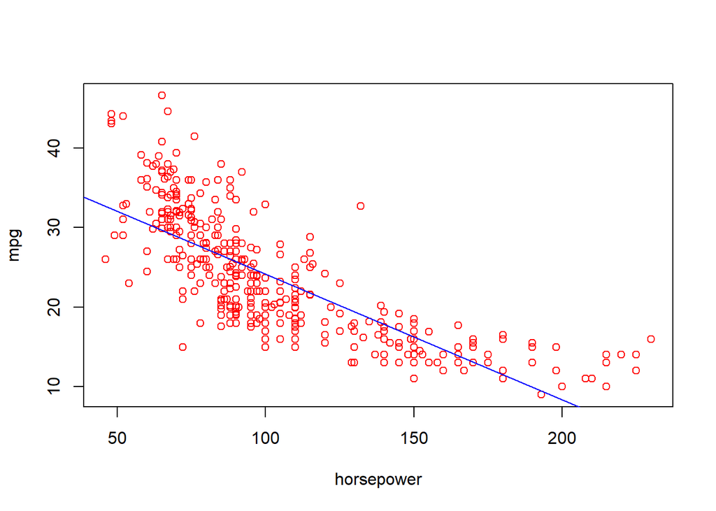

```r
plot(horsepower, mpg, type = 'p', col = 'red')
abline(lm_fit, col = 'blue')
```

- Representa gráficamente los residuos del modelo y comenta posibles problemas que puedas encontrar.

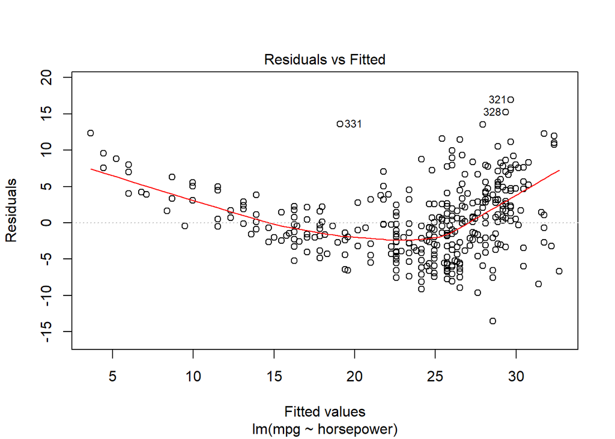

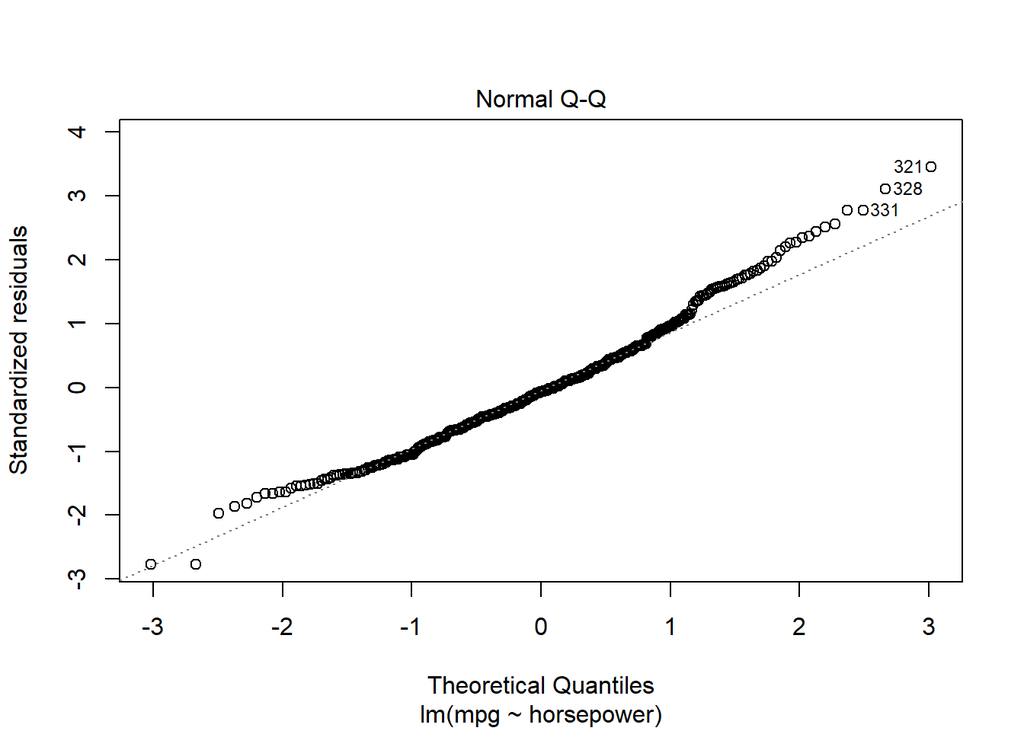

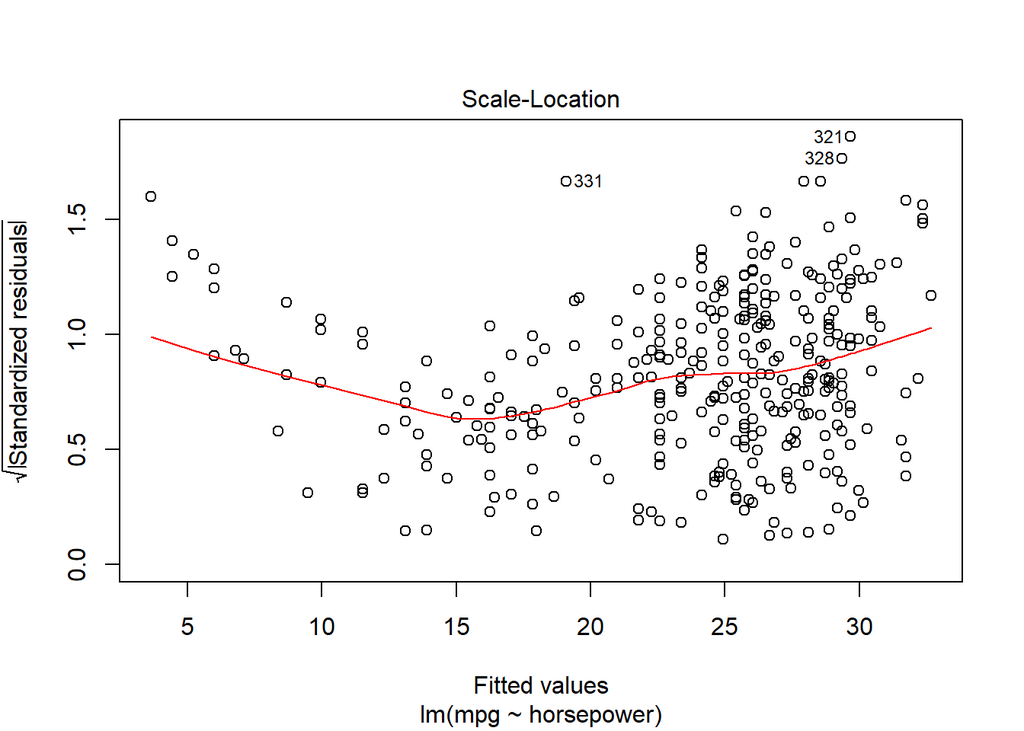

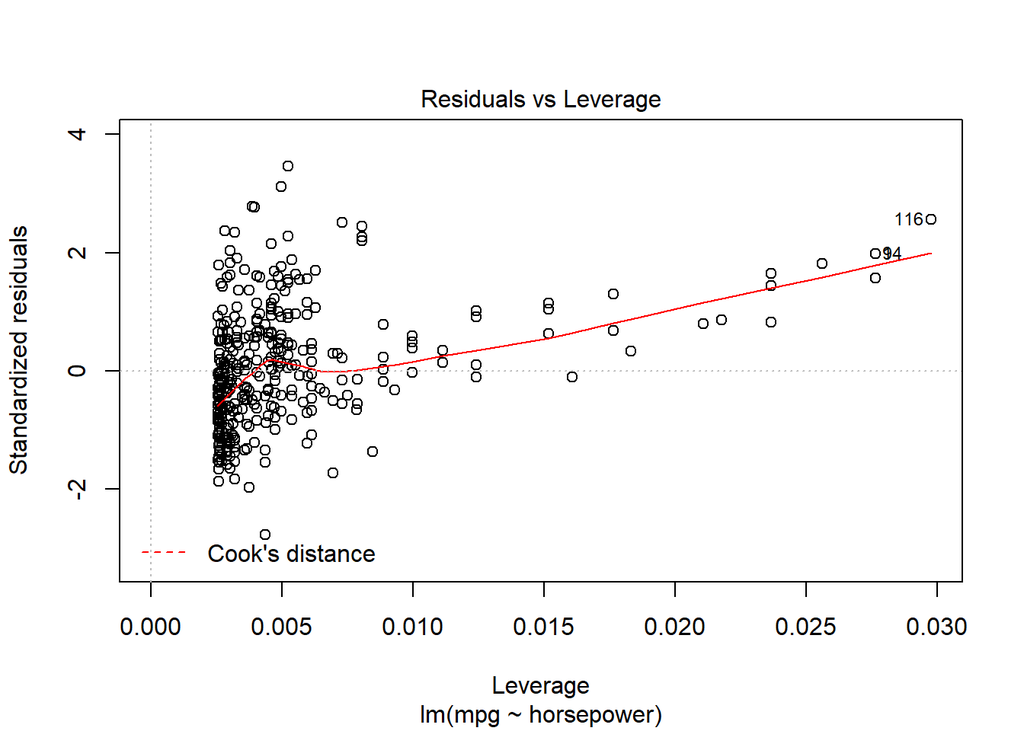

```r
plot(lm_fit)
```

No tienen media cero, ni varianza constante y se desvían de una distribución normal. Existe dependencia de los residuos con la variable respuesta o los valores estimados de la misma. Todo esto indica que el modelo no es adecuado, por simplicidad o falta de información sobre la variable respuesta.

- Intenta otro tipo de análisis en busca de algún insight *sorprendente*.

Complicamos el modelo. Podemos linealizar la dependencia entre `mpg` y `horsepower`, dado que ya la gráfica mostraba que su relación era más compleja. Recuérdese que **la hipótesis de linealidad debe cumplirse siempre en los parámetros de la regresión pero se puede realizar cualquier tipo de transformación previa sobre las variables**. Aplicar logaritmos es una manera general de linealizar:

```r
log_hp <- log(horsepower)
log_mpg <- log(mpg)
```

```r
lm_fit_log <- lm(log_mpg ~ log_hp)
summary(lm_fit_log)
```

```
##
## Call:
## lm(formula = log_mpg ~ log_hp)
##
## Residuals:
##      Min       1Q   Median       3Q      Max
## -0.65230 -0.12176  0.00788  0.11631  0.63730
##
## Coefficients:
##             Estimate Std. Error t value Pr(>|t|)
## (Intercept)  6.96065    0.12149   57.30   <2e-16 ***
## log_hp      -0.84185    0.02641  -31.88   <2e-16 ***
## ---
## Signif. codes:  0 '***' 0.001 '**' 0.01 '*' 0.05 '.' 0.1 ' ' 1
##
## Residual standard error: 0.1793 on 390 degrees of freedom
## Multiple R-squared:  0.7227, Adjusted R-squared:  0.722
## F-statistic:  1016 on 1 and 390 DF,  p-value: < 2.2e-16
```

El $R^2$ mejora respecto al anterior modelo. Representamos los datos y el modelo ajustado:

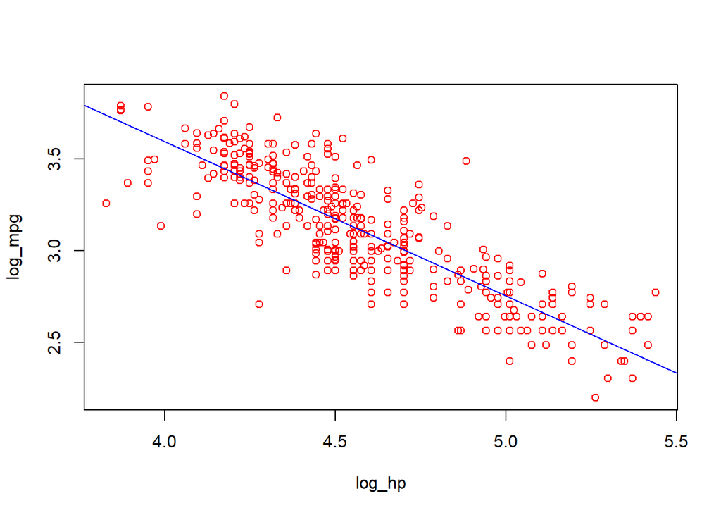

```r
plot(log_hp, log_mpg, type = 'p', col = 'red')
abline(lm_fit_log, col = 'blue')
```

Ahora el valor predicho de `horsepower = 98` se determina según:

```r
new_hp <- data.frame(log_hp = log(98))

predicted_values <- predict(lm_fit_log, new_hp, interval = 'confidence', level = 0.99)
exp(predicted_values)
```

```
##       fit      lwr      upr
## 1 22.2159 21.70118 22.74282
```

Estudiamos los residuos:

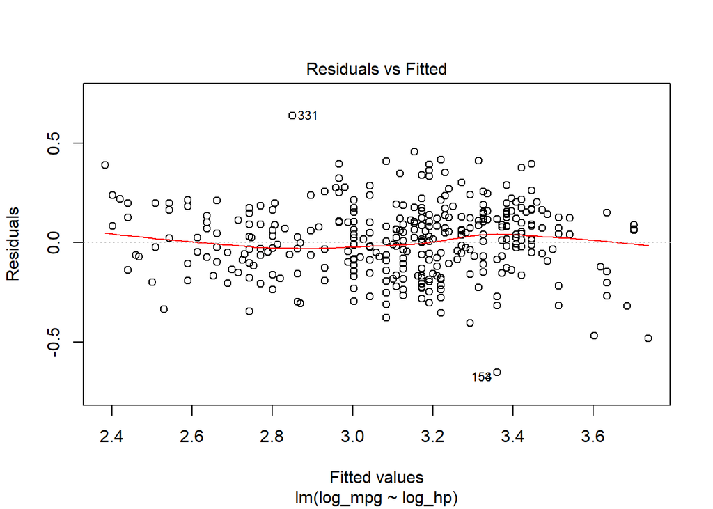

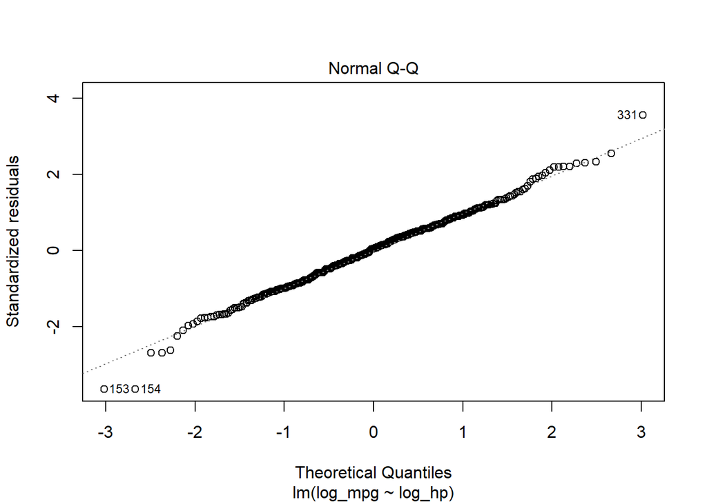

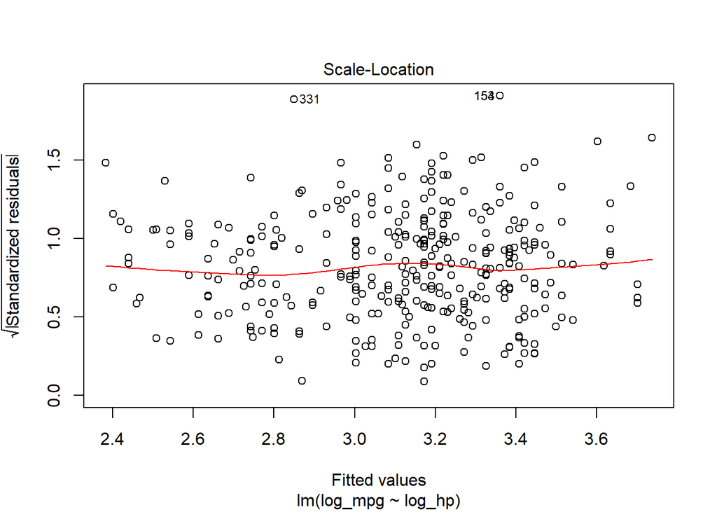

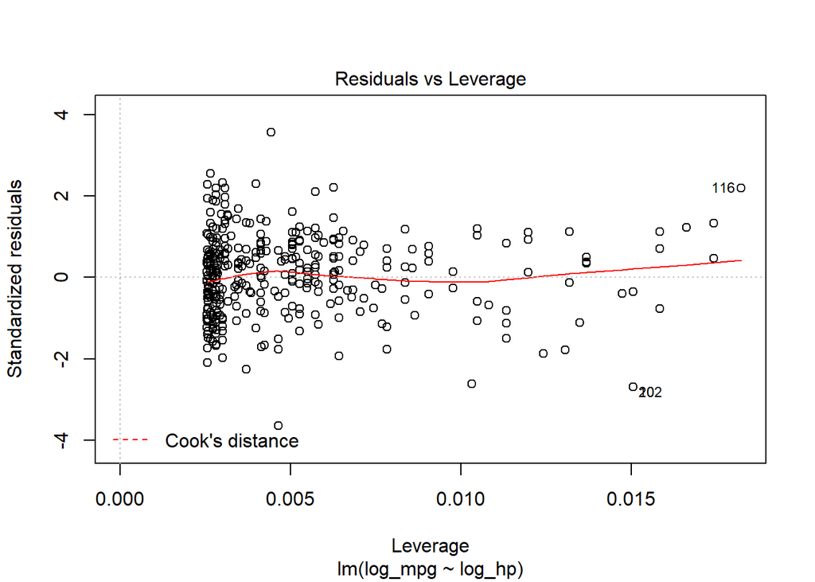

```r
plot(lm_fit_log)
```

Los residuos se pueden considerar más parecidos a los hipotéticos: con media cero, homocedásticos y distribuidos según una normal (salvo *outliers*).

# Ajuste de un modelo lineal múltiple

Para ajustar un modelo de regresión lineal múltiple, la instrucción que se emplea es la misma que en el caso univariante, pero en la fórmula se han de especificar todas las variables que se pretenden considerar, separadas por un `+`. Así, para ajustar un modelo de `Sales` frente a `TV`, `Radio` y `Newspaper` hacemos

```r
lm_fit_sales_all <- lm(Sales ~ TV + Radio + Newspaper, data = advertising)
summary(lm_fit_sales_all)
```

```
##
## Call:
## lm(formula = Sales ~ TV + Radio + Newspaper, data = advertising)
##
## Residuals:
##     Min      1Q  Median      3Q     Max
## -8.8277 -0.8908  0.2418  1.1893  2.8292
##
## Coefficients:
##              Estimate Std. Error t value Pr(>|t|)
## (Intercept)  2.938889   0.311908   9.422   <2e-16 ***
## TV           0.045765   0.001395  32.809   <2e-16 ***
## Radio        0.188530   0.008611  21.893   <2e-16 ***
## Newspaper   -0.001037   0.005871  -0.177     0.86
## ---
## Signif. codes:  0 '***' 0.001 '**' 0.01 '*' 0.05 '.' 0.1 ' ' 1
##
## Residual standard error: 1.686 on 196 degrees of freedom
## Multiple R-squared:  0.8972, Adjusted R-squared:  0.8956
## F-statistic: 570.3 on 3 and 196 DF,  p-value: < 2.2e-16
```

El modelo que se obtiene es

$$Sales = 2.938889 + 0.045765\cdot TV + 0.188530 \cdot Radio - 0.001037 \cdot Newspaper$$

Una llamada equivalente a la que hemos hecho sería

```r
lm_fit_sales_all <- lm(Sales ~ ., data = advertising)
```

ya que el punto quiere decir “todas las demás variables”. Si quieren quitarse variables, se utiliza un `-`. Así, una forma de ajustar un modelo de `Sales` frente a `TV` y `Radio` sería

```r
lm_fit_sales_TV_Radio <- lm(Sales ~ . - Newspaper, data = advertising)
```

```r
summary(lm_fit_sales_TV_Radio)
```

```
##
## Call:
## lm(formula = Sales ~ . - Newspaper, data = advertising)
##
## Residuals:
##     Min      1Q  Median      3Q     Max
## -8.7977 -0.8752  0.2422  1.1708  2.8328
##
## Coefficients:
##             Estimate Std. Error t value Pr(>|t|)
## (Intercept)  2.92110    0.29449   9.919   <2e-16 ***
## TV           0.04575    0.00139  32.909   <2e-16 ***
## Radio        0.18799    0.00804  23.382   <2e-16 ***
## ---
## Signif. codes:  0 '***' 0.001 '**' 0.01 '*' 0.05 '.' 0.1 ' ' 1
##
## Residual standard error: 1.681 on 197 degrees of freedom
## Multiple R-squared:  0.8972, Adjusted R-squared:  0.8962
## F-statistic: 859.6 on 2 and 197 DF,  p-value: < 2.2e-16
```

Cuando hay más de un predictor, el análisis gráfico del modelo es diferente (ya que las representaciones en más de dos dimensiones suelen ser difíciles de leer). En este caso, representamos valores reales frente a predichos y residuos frente a valores reales:

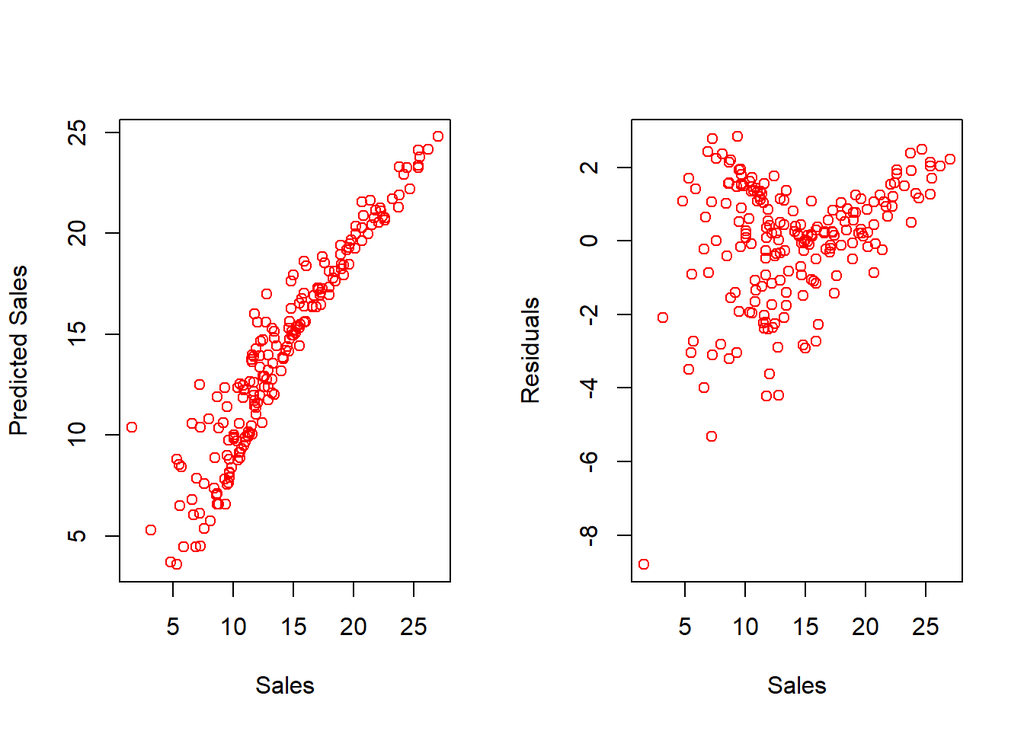

```r
par(mfrow = c(1,2))

plot(advertising$Sales, lm_fit_sales_TV_Radio$fitted.values, type = 'p', col = 'red', xlab = 'Sales', ylab = 'Predicted Sales')
plot(advertising$Sales, lm_fit_sales_TV_Radio$residuals, type = 'p', col = 'red', xlab = 'Sales', ylab = 'Residuals')
```

**Ejercicio:** Sobre el dataset `Auto` de antes:

- Realiza un análisis exploratorio sencillo.

```r
library(DescTools)
Desc(Auto)
```

```
## -------------------------------------------------------------------------
## Describe Auto (data.frame):
##
## data.frame:  392 obs. of  9 variables
##
##   Nr  ColName       Class    NAs  Levels
##   1   mpg           numeric  .
##   2   cylinders     integer  .
##   3   displacement  numeric  .
##   4   horsepower    integer  .
##   5   weight        integer  .
##   6   acceleration  numeric  .
##   7   year          integer  .
##   8   origin        integer  .
##   9   name          factor   .    (301): 1-amc ambassador brougham,
##                                   2-amc ambassador dpl, 3-amc
##                                   ambassador sst, 4-amc concord, 5-amc
##                                   concord d/l, ...
##
##
## -------------------------------------------------------------------------
## 1 - mpg (numeric)
##
##   length       n    NAs  unique     0s   mean  meanCI
##      392     392      0     127      0  23.45   22.67
##           100.0%   0.0%           0.0%          24.22
##
##      .05     .10    .25  median    .75    .90     .95
##    13.00   14.00  17.00   22.75  29.00  34.19   37.00
##
##    range      sd  vcoef     mad    IQR   skew    kurt
##    37.60    7.81   0.33    8.60  12.00   0.45   -0.54
##
## lowest : 9.0, 10.0 (2), 11.0 (4), 12.0 (6), 13.0 (20)
## highest: 43.4, 44.0, 44.3, 44.6, 46.6
```

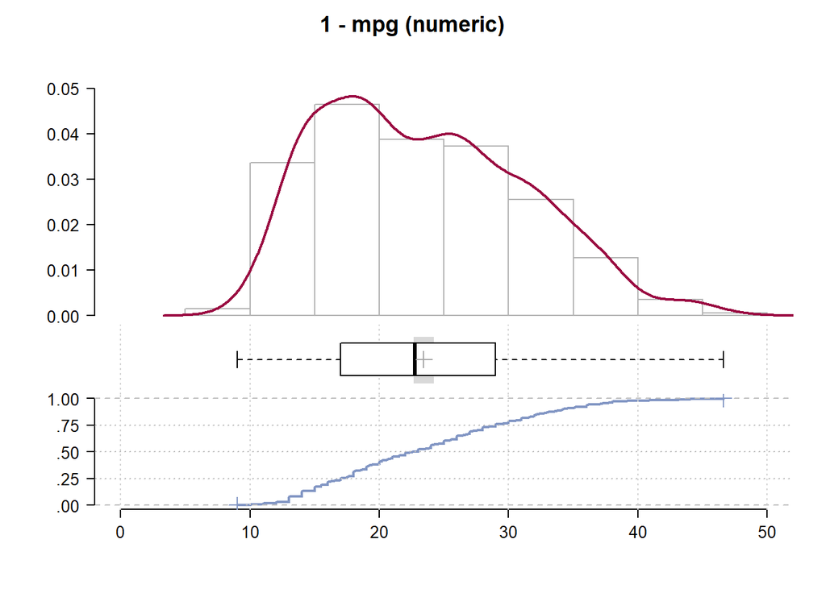

```
## -------------------------------------------------------------------------
## 2 - cylinders (integer)
##
##   length       n    NAs  unique    0s  mean  meanCI
##      392     392      0       5     0  5.47    5.30
##           100.0%   0.0%          0.0%          5.64
##
##      .05     .10    .25  median   .75   .90     .95
##     4.00    4.00   4.00    4.00  8.00  8.00    8.00
##
##    range      sd  vcoef     mad   IQR  skew    kurt
##     5.00    1.71   0.31    0.00  4.00  0.50   -1.40
##
##
##    level  freq   perc  cumfreq  cumperc
## 1      3     4   1.0%        4     1.0%
## 2      4   199  50.8%      203    51.8%
## 3      5     3   0.8%      206    52.6%
## 4      6    83  21.2%      289    73.7%
## 5      8   103  26.3%      392   100.0%
```

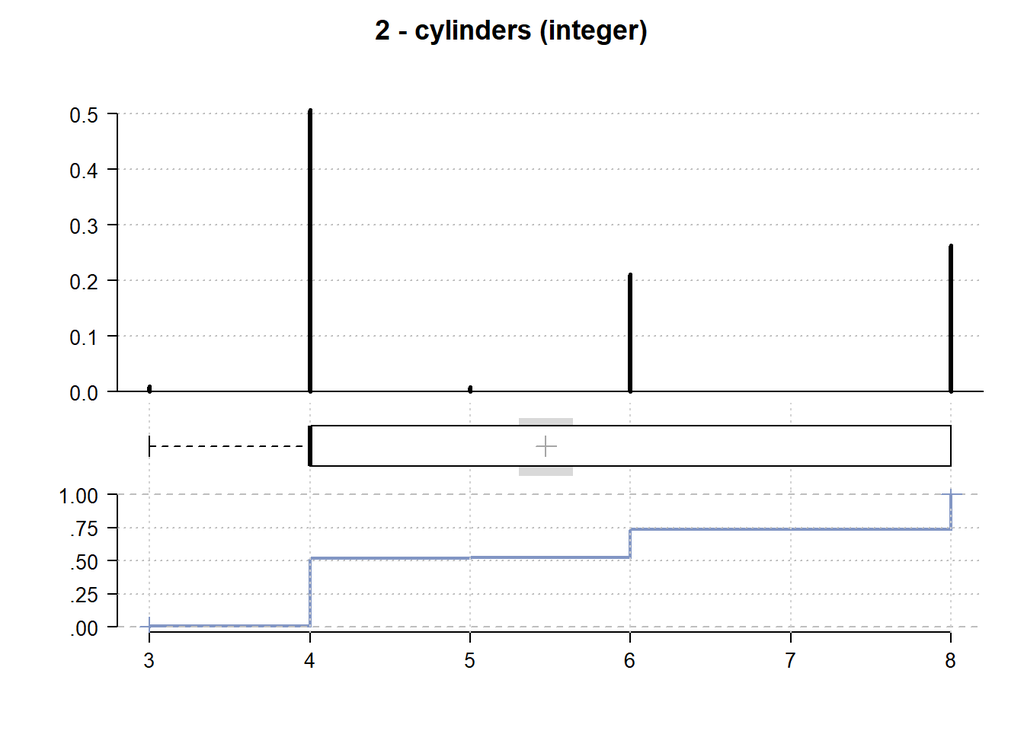

```
## -------------------------------------------------------------------------
## 3 - displacement (numeric)
##
##   length       n     NAs  unique      0s    mean  meanCI
##      392     392       0      81       0  194.41  184.02
##           100.0%    0.0%            0.0%          204.80
##
##      .05     .10     .25  median     .75     .90     .95
##    85.00   90.00  105.00  151.00  275.75  350.00  400.00
##
##    range      sd   vcoef     mad     IQR    skew    kurt
##   387.00  104.64    0.54   90.44  170.75    0.70   -0.79
##
## lowest : 68.0, 70.0 (3), 71.0 (2), 72.0, 76.0
## highest: 400.0 (13), 429.0 (3), 440.0 (2), 454.0, 455.0 (3)
```

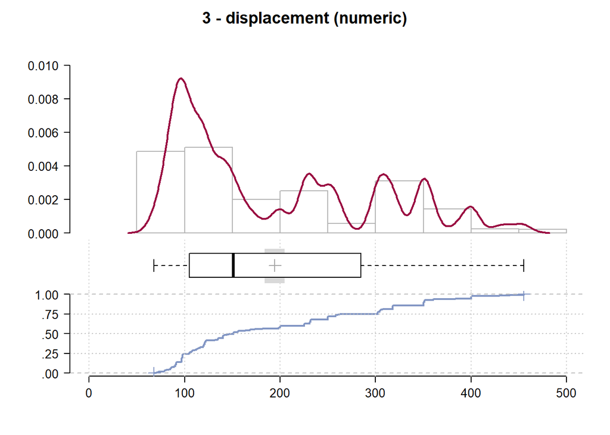

```
## -------------------------------------------------------------------------
## 4 - horsepower (integer)
##
##   length       n    NAs  unique      0s    mean  meanCI
##      392     392      0      93       0  104.47  100.65
##           100.0%   0.0%            0.0%          108.29
##
##      .05     .10    .25  median     .75     .90     .95
##    60.55   67.00  75.00   93.50  126.00  157.70  180.00
##
##    range      sd  vcoef     mad     IQR    skew    kurt
##   184.00   38.49   0.37   28.91   51.00    1.08    0.65
##
## lowest : 46 (2), 48 (3), 49, 52 (4), 53 (2)
## highest: 210, 215 (3), 220, 225 (3), 230
```

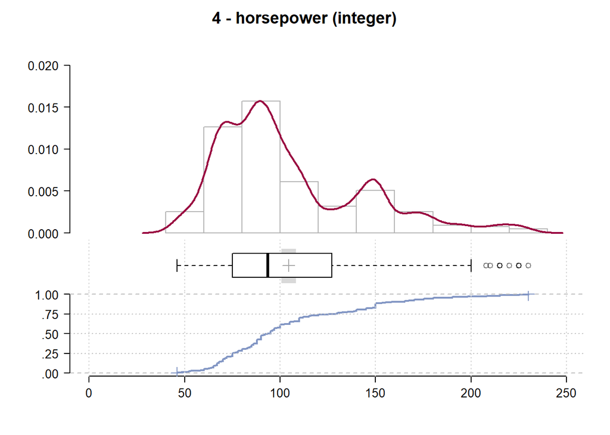

```
## -------------------------------------------------------------------------
## 5 - weight (integer)
##
##     length         n       NAs    unique        0s      mean    meanCI
##        392       392         0       346         0  2'977.58  2'893.24
##               100.0%      0.0%                0.0%            3'061.93
##
##        .05       .10       .25    median       .75       .90       .95
##   1'931.60  1'990.00  2'225.25  2'803.50  3'614.75  4'277.60  4'464.00
##
##      range        sd     vcoef       mad       IQR      skew      kurt
##   3'527.00    849.40      0.29    948.12  1'389.50      0.52     -0.83
##
## lowest : 1'613, 1'649, 1'755, 1'760, 1'773
## highest: 4'951, 4'952, 4'955, 4'997, 5'140
```

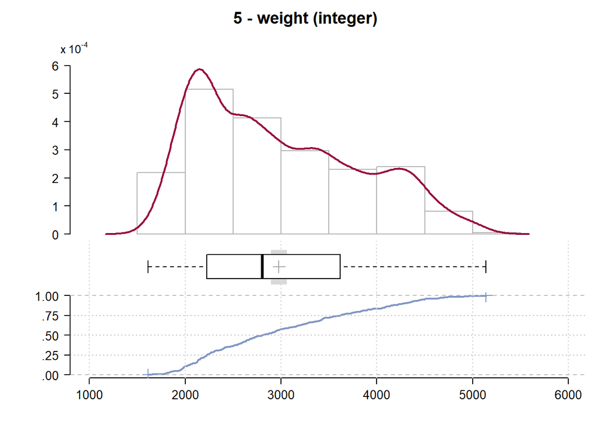

```
## -------------------------------------------------------------------------
## 6 - acceleration (numeric)
##
##   length       n     NAs  unique      0s    mean  meanCI
##      392     392       0      95       0  15.541  15.267
##           100.0%    0.0%            0.0%          15.815
##
##      .05     .10     .25  median     .75     .90     .95
##   11.255  12.000  13.775  15.500  17.025  19.000  20.235
##
##    range      sd   vcoef     mad     IQR    skew    kurt
##   16.800   2.759   0.178   2.520   3.250   0.289   0.406
##
## lowest : 8.0, 8.5 (2), 9.0, 9.5 (2), 10.0 (4)
## highest: 22.2 (2), 23.5, 23.7, 24.6, 24.8
```

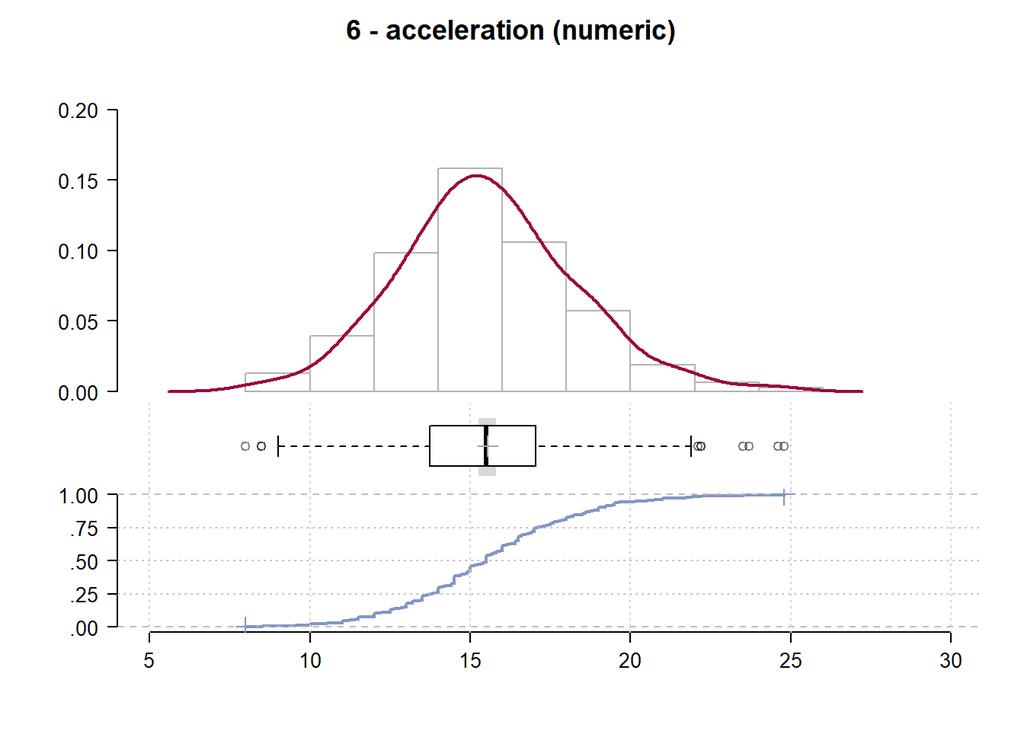

```
## -------------------------------------------------------------------------
## 7 - year (integer)
##
##   length       n    NAs  unique     0s   mean  meanCI
##      392     392      0      13      0  75.98   75.61
##           100.0%   0.0%           0.0%          76.35
##
##      .05     .10    .25  median    .75    .90     .95
##    70.00   71.00  73.00   76.00  79.00  81.00   82.00
##
##    range      sd  vcoef     mad    IQR   skew    kurt
##    12.00    3.68   0.05    4.45   6.00   0.02   -1.18
##
## lowest : 70 (29), 71 (27), 72 (28), 73 (40), 74 (26)
## highest: 78 (36), 79 (29), 80 (27), 81 (28), 82 (30)
```

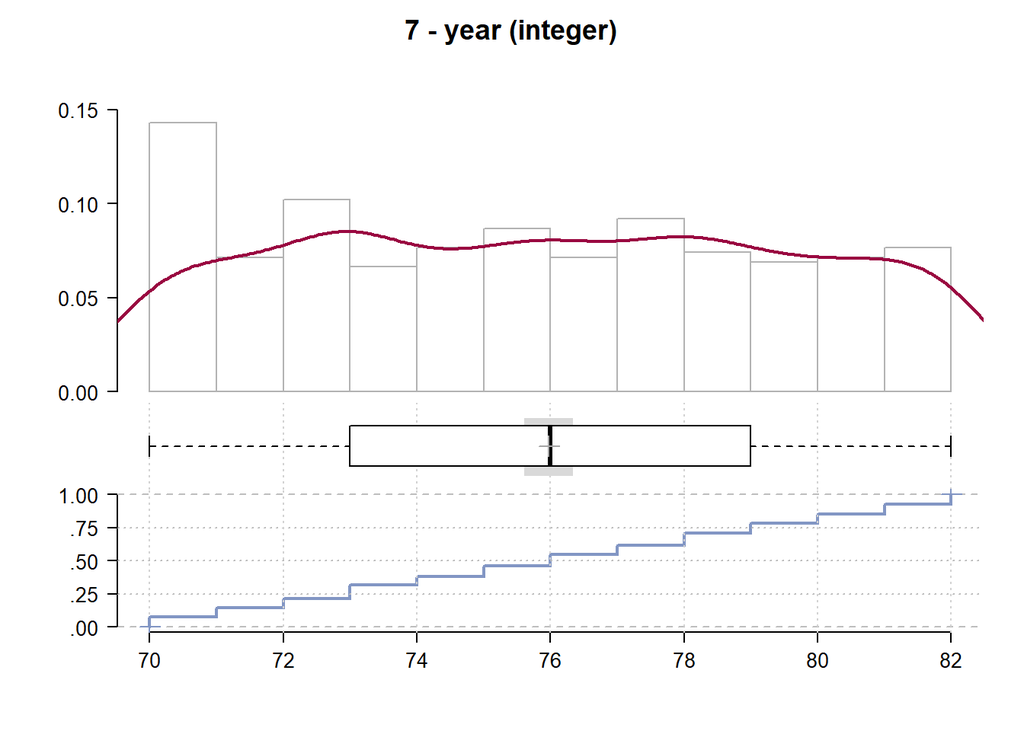

```
## -------------------------------------------------------------------------
## 8 - origin (integer)
##
##   length       n    NAs  unique    0s  mean  meanCI
##      392     392      0       3     0  1.58    1.50
##           100.0%   0.0%          0.0%          1.66
##
##      .05     .10    .25  median   .75   .90     .95
##     1.00    1.00   1.00    1.00  2.00  3.00    3.00
##
##    range      sd  vcoef     mad   IQR  skew    kurt
##     2.00    0.81   0.51    0.00  1.00  0.91   -0.86
##
##
##    level  freq   perc  cumfreq  cumperc
## 1      1   245  62.5%      245    62.5%
## 2      2    68  17.3%      313    79.8%
## 3      3    79  20.2%      392   100.0%
```

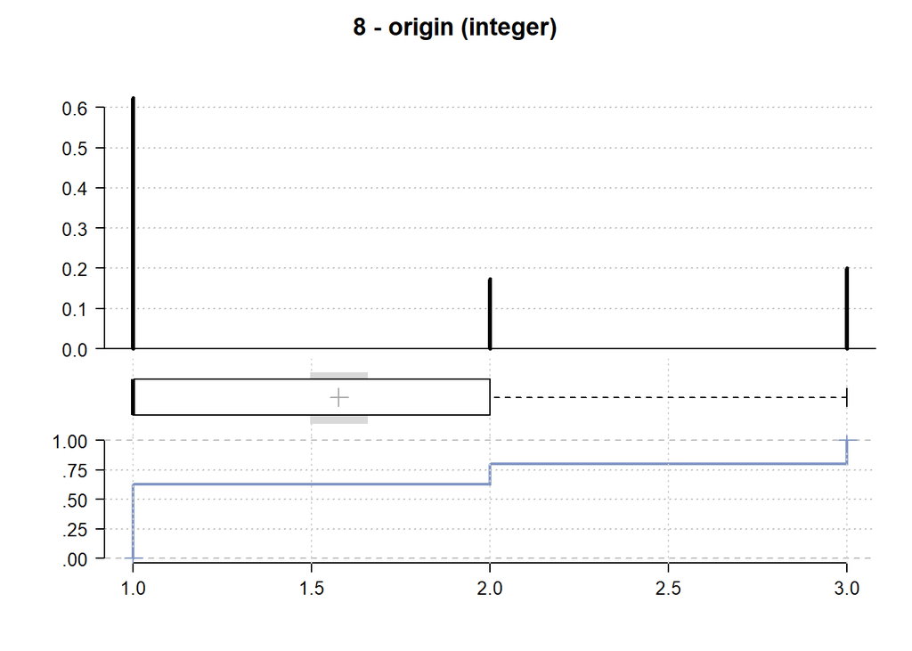

```
## -------------------------------------------------------------------------
## 9 - name (factor)
##
##   length      n    NAs unique levels  dupes
##      392    392      0    301    301      y
##          100.0%   0.0%
##
##                         level  freq  perc  cumfreq  cumperc
## 1                 amc matador     5  1.3%        5     1.3%
## 2                  ford pinto     5  1.3%       10     2.6%
## 3              toyota corolla     5  1.3%       15     3.8%
## 4                 amc gremlin     4  1.0%       19     4.8%
## 5                  amc hornet     4  1.0%       23     5.9%
## 6          chevrolet chevette     4  1.0%       27     6.9%
## 7            chevrolet impala     4  1.0%       31     7.9%
## 8               ford maverick     4  1.0%       35     8.9%
## 9                 peugeot 504     4  1.0%       39     9.9%
## 10              toyota corona     4  1.0%       43    11.0%
## 11  chevrolet caprice classic     3  0.8%       46    11.7%
## 12         chevrolet citation     3  0.8%       49    12.5%
## ... etc.
##  [list output truncated]
```